# Comparison of YNH and ONH on CDTT English Male

## ANOVA results

A repeated-measures two-way analysis of variance was conducted on the adaptive data, with SRT as the outcome measure, Age Group as a between-subjects factor and List as a within-subject factor. There was a significant effect of Age Group, F(1,30) = 11.66, p = 0.00185, with older listeners having a mean SRT that was 0.54 dB higher than the mean SRT of younger listeners. There was no significant effect of List, F(3,90) = 0.29, p = 0.84, and no interaction of Age Group with List, F(3,90) = 0.50, p = 0.68.

```r
# ANOVA (between-group: Age; within-group: List)
summary(with(data, aov(SRT ~ Group*List + Error(factor(SubjectID)/List))))
```

```
##
## Error: factor(SubjectID)
##           Df Sum Sq Mean Sq F value  Pr(>F)
## Group      1  9.301   9.301   11.66 0.00185 **
## Residuals 30 23.926   0.798
## ---
## Signif. codes:  0 '***' 0.001 '**' 0.01 '*' 0.05 '.' 0.1 ' ' 1
##
## Error: factor(SubjectID):List
##            Df Sum Sq Mean Sq F value Pr(>F)
## List        3   0.31  0.1037   0.285  0.836
## Group:List  3   0.55  0.1820   0.500  0.683
## Residuals  90  32.74  0.3638
```

Age Group Difference

```r
mean(data[data$Group == "Older", ]$SRT) - mean(data[data$Group == "Younger", ]$SRT)
```

```
## [1] 0.5391369
```

## Power analysis

Currently, the mean SRT difference between YNH and ONH is 0.53914 dB. The SD of YNH is 0.6679207; the SD of ONH is 0.6833829. The effect size (for two independent groups) is therefore (-11.50595 - -12.04509) / ((0.6833829 + 0.6679207)/2) = 0.7979554. Using G*Power, the power is 0.588762.

If the SRT difference is 0.2 dB, the effect size is 0.2960105, assuming the variances of both groups remains the same. To achieve a power of 0.8 with this new effect size, we need at least 181 participants in each group to say with confidence that we can detect a difference of 0.2 dB.

## Figure 1. Audiogram

Mean audiometric thresholds of 16 older participants (13 females and 3 males; black lines), with standard error of the mean. The 90th, 50th and 10th percentiles of hearing thresholds in otologically normal 70-year-olds are shown in gray (ISO7029:2017; females = solid; males = dashed).

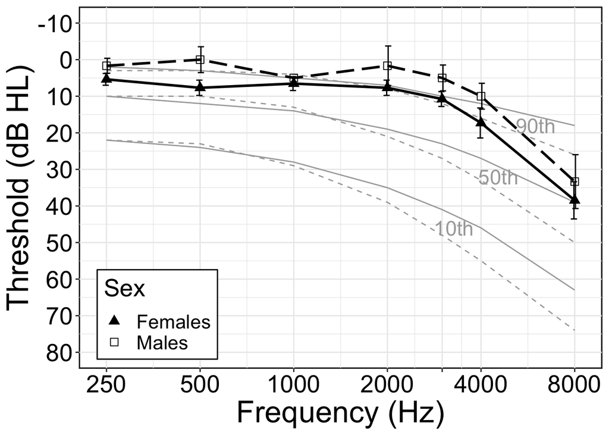

## Figure 2. YNH versus ONH boxplots

Boxplots show the median and interquartile range, with whiskers depicting either the minimum and maximum of the data or 1.5 * Interquartile Range, whichever is smaller. Datapoints for individual participants are overlaid on top of the boxplots.

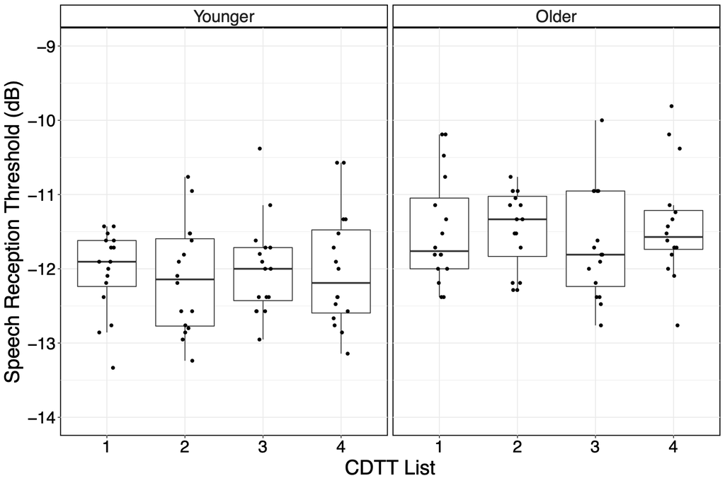

## Figure 3. Psychometric functions

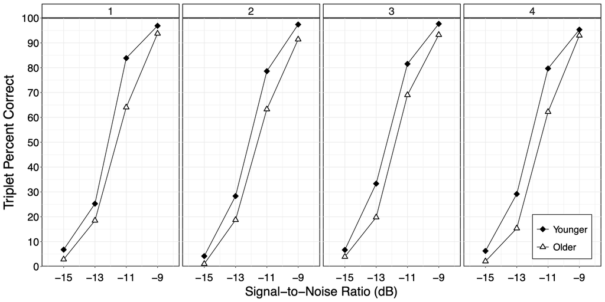